# 2025 SBCFBL Rule Changes

McCade Pearson

2025-06-25

## Thank you for participating in the start of the 2025–26 SBCFBL Season. We’re excited to kick off our sixth great year!

#### One rule change was made at the sole discretion of the commissioner to improve the league: We will now play on a 1/3,000,000th scale instead of a 1/2,000,000th scale. This means everyone’s entry fees should be roughly 25% cheaper this year, accounting for the growing salary cap.

#### Do you vote to change the order in which players are signed in free agency from Alphabetical to a different system?

Starting immediately, free agents signed on the same day will be signed in order of their Fantrax Fantasy ranking from the entire previous NBA regular season, rather than alphabetically as in the past.

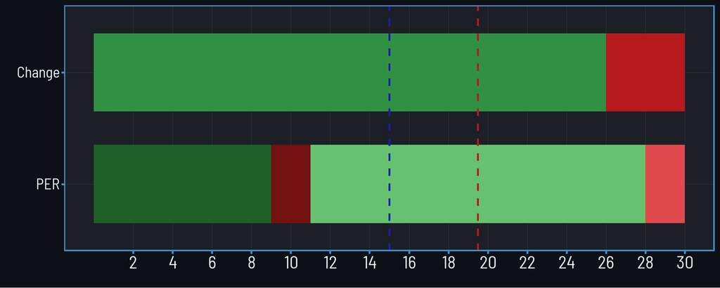

#### Do you vote to change how the League Tax funds are used?

Tax funds will first be used to cover the Fantrax fee, then to cover the first $100 of the League Champion’s trophy. If the tax fund is insufficient to cover these expenses, the remaining balance will be taken from the prize pool. Any tax funds beyond those amounts will be split 50/50 between a charity chosen by the champion and the non–tax-paying teams.

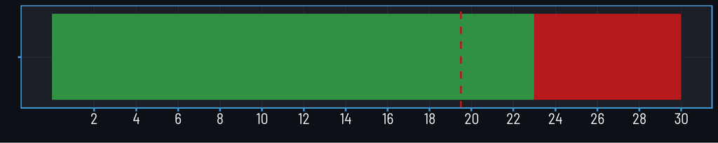

#### Do you vote to change the current Fantrax roster setup?

Fantrax settings will be adjusted to reduce the bench from 14 roster spots to just six, effectively requiring a full starting lineup every day of the season. The total roster limit remains 17 players, with eight starters and three IR spots. Offseason rosters will still have 17 players but no IR spots.

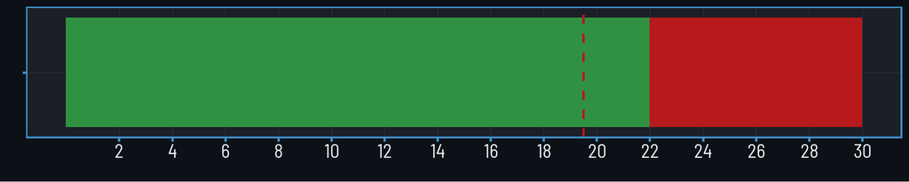

#### All 30 teams have voted, and their votes are listed below.

Individual Team Votes

Logo

Sign Order Change

Player Efficiency Rating

Tax Distribution Change

Roster Limit Changes

[figure not shown]

1

0

1

1

[figure not shown]

0

0

0

0

[figure not shown]

1

1

1

0

[figure not shown]

1

1

1

0

[figure not shown]

0

0

1

1

[figure not shown]

1

0

1

1

[figure not shown]

1

0

1

1

[figure not shown]

1

0

1

1

[figure not shown]

1

0

0

1

[figure not shown]

1

0

1

1

[figure not shown]

1

1

1

1

[figure not shown]

1

0

1

1

[figure not shown]

1

0

1

0

[figure not shown]

1

0

1

1

[figure not shown]

1

0

1

1

[figure not shown]

1

1

1

1

[figure not shown]

1

0

0

1

[figure not shown]

0

1

1

0

[figure not shown]

1

0

1

1

[figure not shown]

0

1

0

1

[figure not shown]

1

0

1

0

[figure not shown]

1

0

1

1

[figure not shown]

1

1

1

0

[figure not shown]

1

1

0

1

[figure not shown]

1

0

1

1

[figure not shown]

1